# Tugas Praktikum 4 MPDW

Bilal Muhammad Thalib (G1401231093)

2025-09-15

# Brief Tugass

Pagi teman-teman, gw akan rincikan untuk tugas MPDW Praktikum 4 kemarin. Tugasnya adalah melakukan pemodelan time series terhadap peubah Y (AQI) dan peubah X, satu saja bebas disertai alasannya (bisa dari cek korelasi, jurnal, dsb). Langkah pemodelannya: - Pemilihan peubah X dan Y - Eksplorasi Data - Pengecekan asumsi autokorelasi maupun asumsi lainnya - Wajib untuk membuat 3 model (Koyck, Distributed Lag, Autoregressive) - Lakukan evaluasi dan perbandingan performa masing-masing model.

## Import Library & Data

```r
# Load necessary libraries
library(ggplot2)
library(dplyr)
library(readr)
library(lubridate)
library(corrplot)
library(forecast)
library(graphics)
library(TTR)
library(TSA)
library(lmtest)
library(orcutt)
library(HoRM)
library(dLagM)
library(dynlm)
library(MLmetrics)
# Load the dataset
data <- read_csv("C:/Users/bilal/Downloads/NewDelhi_Air_quality.csv")
```

```
## ──────────────────────────────────────────────────────── Delimiter: "," chr
## (1): datetime dbl (9): ...1, AQI, CO, no2, o3, pm10, pm25, so2, ts dttm (2):
## timestamp_local, timestamp_utc
```

```r
head(data)
```

```
## # A tibble: 6 × 12
##    ...1   AQI    CO datetime     no2    o3  pm10  pm25   so2 timestamp_local
##   <dbl> <dbl> <dbl> <chr>      <dbl> <dbl> <dbl> <dbl> <dbl> <dttm>
## 1     0  30.2  199. 2022-10-… 0.0469  55.8 10.5   5.64 0.387 2022-10-21 23:00:00
## 2     1  28.2  198. 2022-10-… 0.0465  54.9 10.7   4.62 0.410 2022-10-22 00:00:00
## 3     2  26.6  199. 2022-10-… 0.0469  54.6 11.2   3.52 0.402 2022-10-22 01:00:00
## 4     3  25    202. 2022-10-… 0.0482  55.1 11.1   2.23 0.376 2022-10-22 02:00:00
## 5     4  26    205. 2022-10-… 0.0489  55.8 10.4   1.98 0.339 2022-10-22 03:00:00
## 6     5  26    209. 2022-10-… 0.0502  56.5  9.40  1.79 0.313 2022-10-22 04:00:00
## # ℹ 2 more variables: timestamp_utc <dttm>, ts <dbl>
```

## Pemilihan Peubah X dan Y

```r
# Pemilihan kolom yang akan digunakan
data_cor <- data %>%
  select("AQI", "CO", "no2", "o3", "pm10", "pm25", "so2")
head(data)
```

```
## # A tibble: 6 × 12
##    ...1   AQI    CO datetime     no2    o3  pm10  pm25   so2 timestamp_local
##   <dbl> <dbl> <dbl> <chr>      <dbl> <dbl> <dbl> <dbl> <dbl> <dttm>
## 1     0  30.2  199. 2022-10-… 0.0469  55.8 10.5   5.64 0.387 2022-10-21 23:00:00
## 2     1  28.2  198. 2022-10-… 0.0465  54.9 10.7   4.62 0.410 2022-10-22 00:00:00
## 3     2  26.6  199. 2022-10-… 0.0469  54.6 11.2   3.52 0.402 2022-10-22 01:00:00
## 4     3  25    202. 2022-10-… 0.0482  55.1 11.1   2.23 0.376 2022-10-22 02:00:00
## 5     4  26    205. 2022-10-… 0.0489  55.8 10.4   1.98 0.339 2022-10-22 03:00:00
## 6     5  26    209. 2022-10-… 0.0502  56.5  9.40  1.79 0.313 2022-10-22 04:00:00
## # ℹ 2 more variables: timestamp_utc <dttm>, ts <dbl>
```

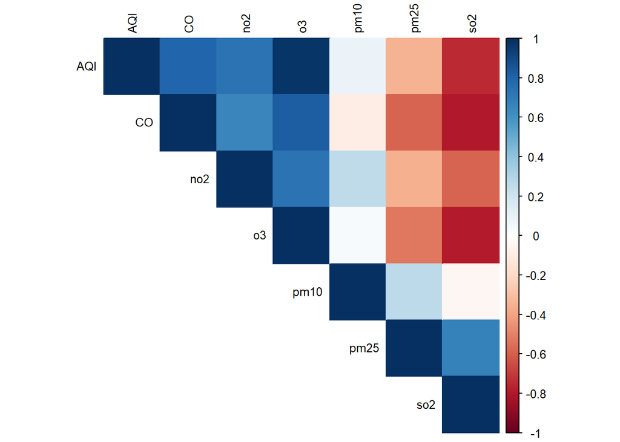

```r
# 3. Hitung matriks korelasi Pearson
cor_matrix <- cor(data_cor, use = "complete.obs", method = "pearson")

corrplot(cor_matrix, method = "color", type = "upper", tl.cex = 0.8, tl.col = "black")
```

```r
# Uji signifikansi korelasi AQI dengan masing-masing variabel polutan

# CO
cor.test(data_cor$AQI, data_cor$CO, method = "pearson")
```

```
##
##  Pearson's product-moment correlation
##
## data:  data_cor$AQI and data_cor$CO
## t = 11.065, df = 70, p-value < 2.2e-16
## alternative hypothesis: true correlation is not equal to 0
## 95 percent confidence interval:
##  0.6942533 0.8687656
## sample estimates:
##       cor
## 0.7976332
```

```r
# NO2
cor.test(data_cor$AQI, data_cor$no2, method = "pearson")
```

```
##
##  Pearson's product-moment correlation
##
## data:  data_cor$AQI and data_cor$no2
## t = 9.1408, df = 70, p-value = 1.46e-13
## alternative hypothesis: true correlation is not equal to 0
## 95 percent confidence interval:
##  0.6102773 0.8278507
## sample estimates:
##       cor
## 0.7376547
```

```r
# O3
cor.test(data_cor$AQI, data_cor$o3, method = "pearson")
```

```
##
##  Pearson's product-moment correlation
##
## data:  data_cor$AQI and data_cor$o3
## t = 35.685, df = 70, p-value < 2.2e-16
## alternative hypothesis: true correlation is not equal to 0
## 95 percent confidence interval:
##  0.9580123 0.9834485
## sample estimates:
##      cor
## 0.973599
```

```r
# PM10
cor.test(data_cor$AQI, data_cor$pm10, method = "pearson")
```

```
##
##  Pearson's product-moment correlation
##
## data:  data_cor$AQI and data_cor$pm10
## t = 0.69325, df = 70, p-value = 0.4904
## alternative hypothesis: true correlation is not equal to 0
## 95 percent confidence interval:
##  -0.1520007  0.3083455
## sample estimates:
##        cor
## 0.08257568
```

```r
# PM2.5
cor.test(data_cor$AQI, data_cor$pm25, method = "pearson")
```

```
##
##  Pearson's product-moment correlation
##
## data:  data_cor$AQI and data_cor$pm25
## t = -3.0921, df = 70, p-value = 0.002854
## alternative hypothesis: true correlation is not equal to 0
## 95 percent confidence interval:
##  -0.5353318 -0.1250275
## sample estimates:
##        cor
## -0.3466552
```

```r
# SO2
cor.test(data_cor$AQI, data_cor$so2, method = "pearson")
```

```
##
##  Pearson's product-moment correlation
##
## data:  data_cor$AQI and data_cor$so2
## t = -9.2735, df = 70, p-value = 8.351e-14
## alternative hypothesis: true correlation is not equal to 0
## 95 percent confidence interval:
##  -0.8311769 -0.6169264
## sample estimates:
##        cor
## -0.7424781
```

Berdasarkan hasil eksplorasi data dan uji korelasi, peubah X yang dipilih adalah O3 (Ozone) karena memiliki korelasi paling tinggi terhadap AQI, sebesar 0.974 dan nilai p-value < 0.05.

## Eksplorasi Data

### Cek Kekonsistenan Data

```r
data <- data %>%
  select("AQI", "o3", "timestamp_local")
head(data)
```

```
## # A tibble: 6 × 3
##     AQI    o3 timestamp_local
##   <dbl> <dbl> <dttm>
## 1  30.2  55.8 2022-10-21 23:00:00
## 2  28.2  54.9 2022-10-22 00:00:00
## 3  26.6  54.6 2022-10-22 01:00:00
## 4  25    55.1 2022-10-22 02:00:00
## 5  26    55.8 2022-10-22 03:00:00
## 6  26    56.5 2022-10-22 04:00:00
```

```r
data$time <- ymd_hms(data$timestamp_local)
```

Terdapat 3 baris yang tidak memiliki format data yang konsisten

```r
which(is.na(ymd_hms(data$timestamp_local)))
```

```
## [1]  2 26 50
```

```r
data[c(2, 26, 50), ]
```

```
## # A tibble: 3 × 4
##     AQI    o3 timestamp_local     time
##   <dbl> <dbl> <dttm>              <dttm>
## 1  28.2  54.9 2022-10-22 00:00:00 NA
## 2  28    61.5 2022-10-23 00:00:00 NA
## 3  27    58.7 2022-10-24 00:00:00 NA
```

```r
data$timestamp_local[c(2, 26, 50)] <- paste0(data$timestamp_local[c(2, 26, 50)], "T00:00:00")
```

```r
data$time <- ymd_hms(data$timestamp_local)
```

```r
data[c(2, 26, 50), ]
```

```
## # A tibble: 3 × 4
##     AQI    o3 timestamp_local     time
##   <dbl> <dbl> <dttm>              <dttm>
## 1  28.2  54.9 2022-10-21 17:00:00 2022-10-21 17:00:00
## 2  28    61.5 2022-10-22 17:00:00 2022-10-22 17:00:00
## 3  27    58.7 2022-10-23 17:00:00 2022-10-23 17:00:00
```

Baris dengan format data yang tidak konsisten sudah ditangani

### Visualisasi Data

```r
summary(data$AQI)
```

```
##    Min. 1st Qu.  Median    Mean 3rd Qu.    Max.
##   19.00   25.00   27.00   26.18   28.00   32.00
```

```r
summary(data$o3)
```

```
##    Min. 1st Qu.  Median    Mean 3rd Qu.    Max.
##   41.48   53.64   57.22   56.57   60.08   68.66
```

```r
sd(data$AQI, na.rm = TRUE)
```

```
## [1] 3.05465
```

```r
sd(data$o3, na.rm = TRUE)
```

```
## [1] 6.431549
```

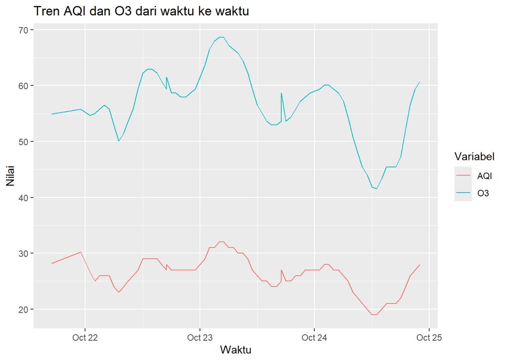

```r
ggplot(data, aes(x = time)) +
  geom_line(aes(y = AQI, color = "AQI")) +
  geom_line(aes(y = o3, color = "O3")) +
  labs(title = "Tren AQI dan O3 dari waktu ke waktu",
       x = "Waktu", y = "Nilai",
       color = "Variabel")
```

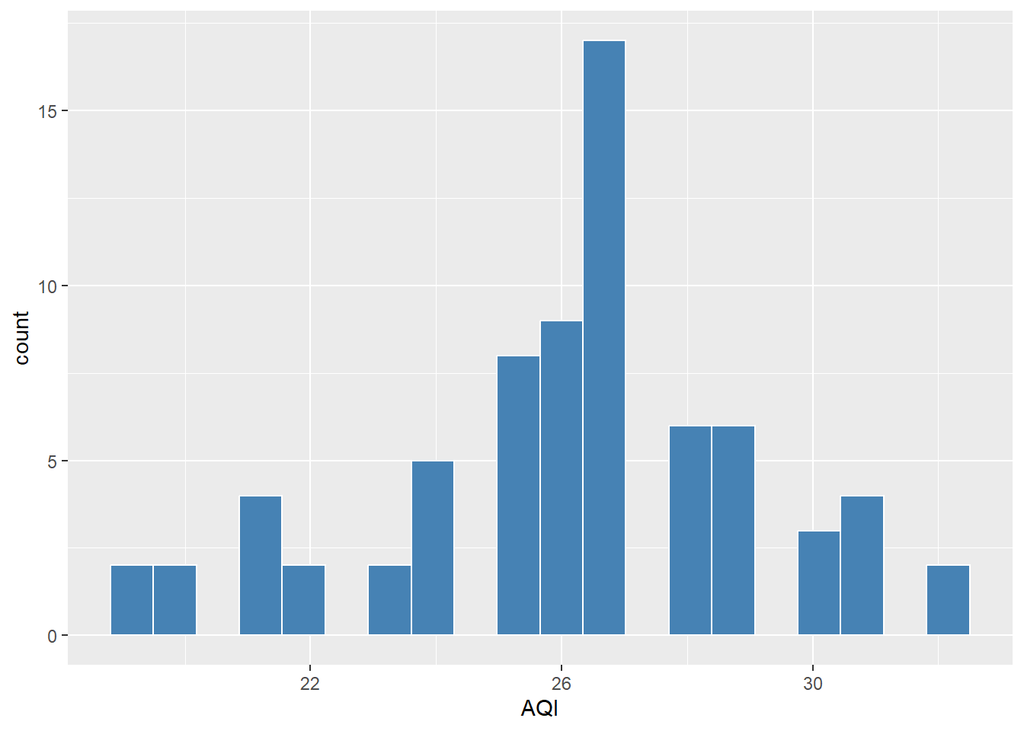

```r
ggplot(data, aes(x = AQI)) + geom_histogram(bins = 20, fill = "steelblue", color = "white")
```

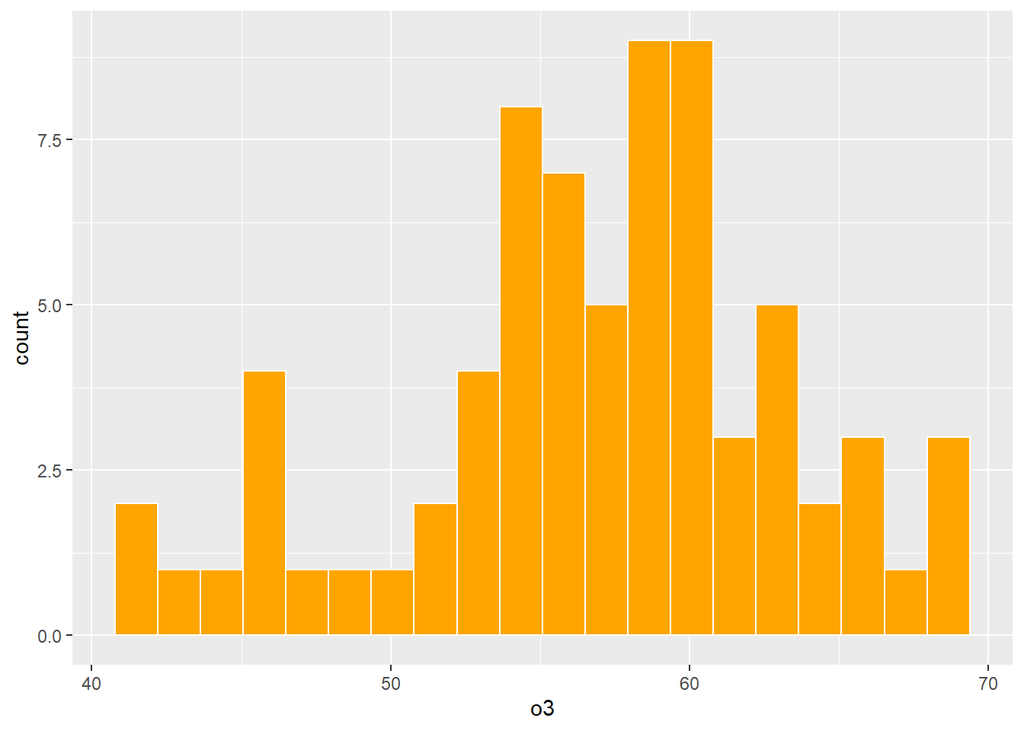

```r
ggplot(data, aes(x = o3)) + geom_histogram(bins = 20, fill = "orange", color = "white")
```

## Pengecekan Asumsi Autokorelasi dan Asumsi Lainnya

### Regresi

```r
model <- lm(AQI ~ o3, data = data)
summary(model)
```

```
##
## Call:
## lm(formula = AQI ~ o3, data = data)
##
## Residuals:
##     Min      1Q  Median      3Q     Max
## -0.5039 -0.4436 -0.1381  0.1810  4.3810
##
## Coefficients:
##             Estimate Std. Error t value Pr(>|t|)
## (Intercept)  0.02128    0.73771   0.029    0.977
## o3           0.46241    0.01296  35.685   <2e-16 ***
## ---
## Signif. codes:  0 '***' 0.001 '**' 0.01 '*' 0.05 '.' 0.1 ' ' 1
##
## Residual standard error: 0.7022 on 70 degrees of freedom
## Multiple R-squared:  0.9479, Adjusted R-squared:  0.9472
## F-statistic:  1273 on 1 and 70 DF,  p-value: < 2.2e-16
```

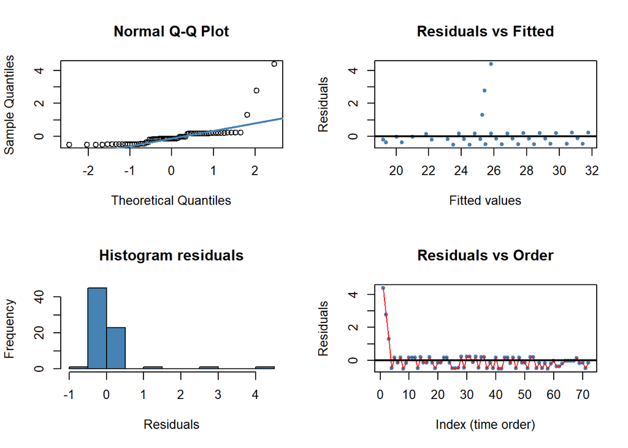

```r
sisaan  <- resid(model)    # residuals(model)
fitValue <- fitted(model)  # atau predict(model)

par(mfrow = c(2,2))

# QQ-plot residual
qqnorm(sisaan); qqline(sisaan, col = "steelblue", lwd = 2)

# Residuals vs Fitted
plot(fitValue, sisaan, col = "steelblue", pch = 20,
     xlab = "Fitted values", ylab = "Residuals", main = "Residuals vs Fitted")
abline(h = 0, lwd = 2)

# Histogram residual
hist(sisaan, main = "Histogram residuals", xlab = "Residuals", col = "steelblue")

# Residual vs Order (index)
plot(seq_along(sisaan), sisaan, col = "steelblue", pch = 20,
     xlab = "Index (time order)", ylab = "Residuals", main = "Residuals vs Order")
lines(seq_along(sisaan), sisaan, col = "red")
abline(h = 0, lwd = 2)
```

```r
#Melihat Sisaan Menyebar Normal/Tidak
#H0: sisaan mengikuti sebaran normal
#H1: sisaan tidak mengikuti sebaran normal
shapiro.test(sisaan)
```

```
##
##  Shapiro-Wilk normality test
##
## data:  sisaan
## W = 0.51931, p-value = 5.517e-14
```

```r
ks.test(sisaan, "pnorm", mean=mean(sisaan), sd=sd(sisaan))
```

```
##
##  Asymptotic one-sample Kolmogorov-Smirnov test
##
## data:  sisaan
## D = 0.33037, p-value = 2.988e-07
## alternative hypothesis: two-sided
```

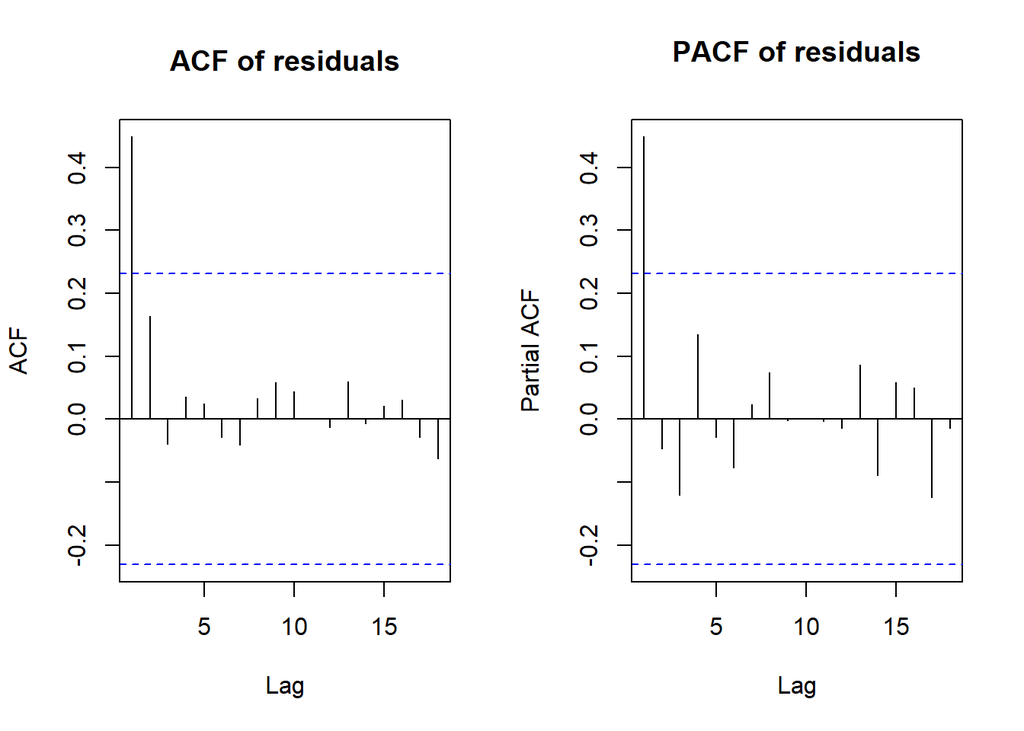

```r
par(mfrow = c(1,2))
acf(sisaan, main = "ACF of residuals")
pacf(sisaan, main = "PACF of residuals")
```

```r
#Deteksi autokorelasi dengan uji-Durbin Watson
#H0: tidak ada autokorelasi
#H1: ada autokorelasi
dwtest(model)
```

```
##
##  Durbin-Watson test
##
## data:  model
## DW = 0.54636, p-value = 3.207e-14
## alternative hypothesis: true autocorrelation is greater than 0
```

Berdasarkan uji uji asumsi diatas, terdapat bukti adanya autokorelasi. Didukung juga dengan p-value < 0.05, maka dapat disimpulkan bahwa tolak H0, cukup bukti mengatakan adanya autokorelasi positif kuat.

## Pembuatan Model Time Series

```r
data <- data[order(data$time), ]   # urutkan berdasarkan waktu
```

```r
n <- nrow(data)
n_train <- floor(0.7 * n)

train_data <- data[1:n_train, ]
test_data  <- data[(n_train+1):n, ]
```

```r
train.ts<-ts(train_data)
test.ts<-ts(test_data)
data.ts<-ts(data)
```

### Model Koyck

```r
#MODEL KOYCK
model.koyck <- koyckDlm(y = train_data$AQI, x = train_data$o3)

summary(model.koyck)
```

```
##
## Call:
## "Y ~ (Intercept) + Y.1 + X.t"
##
## Residuals:
##       Min        1Q    Median        3Q       Max
## -1.367022 -0.502030 -0.001361  0.386510  3.158195
##
## Coefficients:
##             Estimate Std. Error t value Pr(>|t|)
## (Intercept)  1.47156    1.52019   0.968 0.338101
## Y.1          0.48218    0.13113   3.677 0.000616 ***
## X.t          0.21460    0.06804   3.154 0.002836 **
## ---
## Signif. codes:  0 '***' 0.001 '**' 0.01 '*' 0.05 '.' 0.1 ' ' 1
##
## Residual standard error: 0.7878 on 46 degrees of freedom
## Multiple R-Squared: 0.887,   Adjusted R-squared: 0.8821
## Wald test: 157.8 on 2 and 46 DF,  p-value: < 2.2e-16
##
## Diagnostic tests:
## NULL
##
##                             alpha      beta      phi
## Geometric coefficients:  2.841836 0.2146049 0.482179
```

```r
AIC(model.koyck)
```

```
## [1] 120.5825
```

```r
BIC(model.koyck)
```

```
## [1] 128.1498
```

Dari hasil diatas terlihat bahwa P-value < 0.05, menunjukan peubah berpengaruh signifikan terhadap y

#### Peramalan dan Akurasi

Berikut adalah hasil peramalan y untuk 5 periode kedepan menggunakan model koyck

```r
fore.koyck <- forecast(model.koyck,
                       x = test_data$o3,
                       h = 5)
fore.koyck
```

```
## $forecasts
## [1] 27.23068 27.49540 27.62305 27.53110 27.33326
##
## $call
## forecast.koyckDlm(model = model.koyck, x = test_data$o3, h = 5)
##
## attr(,"class")
## [1] "forecast.koyckDlm" "dLagM"
```

```r
#akurasi data test
y_pred <- as.numeric(fore.koyck$forecasts)

# Data aktual (test set)
y_true <- test_data$AQI[1:length(y_pred)]

# Hitung MAPE
mape_koyck <- mean(abs((y_true - y_pred) / y_true)) * 100
mape_koyck
```

```
## [1] 1.440818
```

```r
#akurasi data training
GoF(model.koyck)
```

```
##              n       MAE          MPE       MAPE      sMAPE      MASE      MSE
## model.koyck 49 0.5475574 -0.001048321 0.02020772 0.02024271 0.6704784 0.582588
##                  MRAE    GMRAE
## model.koyck 598622621 2342.948
```

### Regresi Distributed Lag

```r
#MODEL REGRESI DISTRIBUTED LAG
model.dlm <- dlm(y = train_data$AQI, x = train_data$o3, q =1)
summary(model.dlm)
```

```
##
## Call:
## lm(formula = model.formula, data = design)
##
## Residuals:
##     Min      1Q  Median      3Q     Max
## -0.5905 -0.3729 -0.1057  0.1569  4.3103
##
## Coefficients:
##             Estimate Std. Error t value Pr(>|t|)
## (Intercept)  0.77710    1.32017   0.589    0.559
## x.t          0.46386    0.05503   8.429 6.96e-11 ***
## x.1         -0.01395    0.05467  -0.255    0.800
## ---
## Signif. codes:  0 '***' 0.001 '**' 0.01 '*' 0.05 '.' 0.1 ' ' 1
##
## Residual standard error: 0.7355 on 46 degrees of freedom
## Multiple R-squared:  0.9015, Adjusted R-squared:  0.8972
## F-statistic: 210.4 on 2 and 46 DF,  p-value: < 2.2e-16
##
## AIC and BIC values for the model:
##        AIC      BIC
## 1 113.8565 121.4237
```

Dari hasil diatas terlihat bahwa P-value < 0.05, menunjukan peubah berpengaruh signifikan terhadap y

#### Peramalan dan Akurasi

Berikut adalah hasil peramalan y untuk 5 periode kedepan menggunakan model dlm

```r
fore.dlm <- forecast(model.dlm,
                       x = test_data$o3,
                       h = 5)
fore.dlm
```

```
## $forecasts
## [1] 27.49667 27.81847 27.80849 27.47672 27.15491
##
## $call
## forecast.dlm(model = model.dlm, x = test_data$o3, h = 5)
##
## attr(,"class")
## [1] "forecast.dlm" "dLagM"
```

```r
#akurasi data test
y_pred <- as.numeric(fore.dlm$forecasts)

# Data aktual (test set)
y_true <- test_data$AQI[1:length(y_pred)]

# Hitung MAPE
mape_dlm <- mean(abs((y_true - y_pred) / y_true)) * 100
mape_dlm
```

```
## [1] 1.10223
```

```r
#akurasi data training
GoF(model.dlm)
```

```
##            n       MAE           MPE       MAPE      sMAPE      MASE       MSE
## model.dlm 49 0.3704892 -0.0006675812 0.01343175 0.01362861 0.4536602 0.5078643
##                 MRAE    GMRAE
## model.dlm 1017040006 1685.324
```

#### Lag Optimum

```r
#penentuan lag optimum
finiteDLMauto(formula = AQI ~ o3,
              data = data.frame(train_data), q.min = 1, q.max = 10,
              model.type = "dlm", error.type = "AIC", trace = TRUE)
```

```
##    q - k    MASE       AIC       BIC    GMRAE   MBRAE R.Adj.Sq Ljung-Box
## 4      4 0.31105  20.50682  33.30731 2628.613 0.44412  0.98536 0.2079854
## 3      3 0.32118  21.89426  32.99514 2036.227 0.44773  0.98471 0.2007899
## 5      5 0.30442  22.74122  37.19452 1929.305 0.43373  0.98503 0.2085607
## 6      6 0.30418  24.57744  40.63515 1403.915 0.42034  0.98480 0.2331282
## 8      8 0.30402  25.41792  44.53228 2031.082 0.44543  0.98461 0.3386224
## 9      9 0.29780  25.69543  46.25829 2305.645 0.45322  0.98351 0.4342411
## 7      7 0.31912  26.48416  44.09616 1921.810 0.42909  0.98451 0.2797819
## 10    10 0.30015  27.64984  49.60528 2866.062 0.45827  0.98207 0.3816248
## 2      2 0.35131  39.99595  49.35195 1862.115 0.44657  0.97698 0.1166401
## 1      1 0.45366 113.85646 121.42374 1685.324 0.39657  0.89718 0.1767099
```

```r
#model dlm dengan lag optimum
model.dlm2 <- dlm(x = train_data$o3,y = train_data$AQI , q = 9)
summary(model.dlm2)
```

```
##
## Call:
## lm(formula = model.formula, data = design)
##
## Residuals:
##      Min       1Q   Median       3Q      Max
## -0.44595 -0.21626 -0.00011  0.18238  0.39863
##
## Coefficients:
##             Estimate Std. Error t value Pr(>|t|)
## (Intercept)  0.54510    0.99627   0.547    0.588
## x.t          0.44377    0.02803  15.831 4.15e-16 ***
## x.1          0.03909    0.03731   1.048    0.303
## x.2         -0.04377    0.03723  -1.176    0.249
## x.3          0.05138    0.03678   1.397    0.173
## x.4         -0.02782    0.03679  -0.756    0.455
## x.5          0.01564    0.03710   0.421    0.676
## x.6         -0.02401    0.04144  -0.579    0.567
## x.7         -0.05287    0.05710  -0.926    0.362
## x.8          0.09799    0.05810   1.686    0.102
## x.9         -0.04728    0.03396  -1.392    0.174
## ---
## Signif. codes:  0 '***' 0.001 '**' 0.01 '*' 0.05 '.' 0.1 ' ' 1
##
## Residual standard error: 0.2888 on 30 degrees of freedom
## Multiple R-squared:  0.9876, Adjusted R-squared:  0.9835
## F-statistic: 239.5 on 10 and 30 DF,  p-value: < 2.2e-16
##
## AIC and BIC values for the model:
##        AIC      BIC
## 1 25.69543 46.25829
```

```r
fore.dlm2 <- forecast(model.dlm2,
                       x = test_data$o3,
                       h = 5)
fore.dlm2
```

```
## $forecasts
## [1] 27.25029 28.28800 27.52439 27.40056 27.09678
##
## $call
## forecast.dlm(model = model.dlm2, x = test_data$o3, h = 5)
##
## attr(,"class")
## [1] "forecast.dlm" "dLagM"
```

```r
#akurasi data test
y_pred <- as.numeric(fore.dlm2$forecasts)

# Data aktual (test set)
y_true <- test_data$AQI[1:length(y_pred)]

# Hitung MAPE
mape_dlm2 <- mean(abs((y_true - y_pred) / y_true)) * 100
mape_dlm2
```

```
## [1] 1.099227
```

```r
#akurasi data training
GoF(model.dlm2)
```

```
##             n       MAE           MPE       MAPE       sMAPE      MASE
## model.dlm2 41 0.2159042 -7.063134e-05 0.00793985 0.007939568 0.2977989
##                   MSE       MRAE    GMRAE
## model.dlm2 0.06102173 1032790930 2305.645
```

### Model Autoregressive

```r
#MODEL AUTOREGRESSIVE
model.ardl <- ardlDlm(y = train_data$AQI, x = train_data$o3, p = 1 , q = 1)
summary(model.ardl)
```

```
##
## Time series regression with "ts" data:
## Start = 2, End = 50
##
## Call:
## dynlm(formula = as.formula(model.text), data = data, start = 1)
##
## Residuals:
##      Min       1Q   Median       3Q      Max
## -1.15215 -0.28134 -0.03654  0.29264  2.95448
##
## Coefficients:
##             Estimate Std. Error t value Pr(>|t|)
## (Intercept)  0.03824    1.09432   0.035 0.972278
## X.t          0.47577    0.04524  10.517 1.05e-13 ***
## X.1         -0.25274    0.06680  -3.783 0.000454 ***
## Y.1          0.51586    0.10691   4.825 1.64e-05 ***
## ---
## Signif. codes:  0 '***' 0.001 '**' 0.01 '*' 0.05 '.' 0.1 ' ' 1
##
## Residual standard error: 0.6037 on 45 degrees of freedom
## Multiple R-squared:  0.9351, Adjusted R-squared:  0.9307
## F-statistic:   216 on 3 and 45 DF,  p-value: < 2.2e-16
```

```r
AIC(model.ardl)
```

```
## [1] 95.42257
```

```r
BIC(model.ardl)
```

```
## [1] 104.8817
```

```r
model.ardl <- ardlDlm(formula = AQI ~ o3,
                         data = train_data,p = 1 , q = 1)
summary(model.ardl)
```

```
##
## Time series regression with "ts" data:
## Start = 2, End = 50
##
## Call:
## dynlm(formula = as.formula(model.text), data = data)
##
## Residuals:
##      Min       1Q   Median       3Q      Max
## -1.15215 -0.28134 -0.03654  0.29264  2.95448
##
## Coefficients:
##             Estimate Std. Error t value Pr(>|t|)
## (Intercept)  0.03824    1.09432   0.035 0.972278
## o3.t         0.47577    0.04524  10.517 1.05e-13 ***
## o3.1        -0.25274    0.06680  -3.783 0.000454 ***
## AQI.1        0.51586    0.10691   4.825 1.64e-05 ***
## ---
## Signif. codes:  0 '***' 0.001 '**' 0.01 '*' 0.05 '.' 0.1 ' ' 1
##
## Residual standard error: 0.6037 on 45 degrees of freedom
## Multiple R-squared:  0.9351, Adjusted R-squared:  0.9307
## F-statistic:   216 on 3 and 45 DF,  p-value: < 2.2e-16
```

```r
AIC(model.ardl)
```

```
## [1] 95.42257
```

```r
BIC(model.ardl)
```

```
## [1] 104.8817
```

#### Peramalan dan Akurasi

```r
fore.ardl <- forecast(model.ardl,
                       x = test_data$o3,
                       h = 5)
fore.ardl
```

```
## $forecasts
## [1] 27.38796 27.74761 27.75237 27.41453 27.08072
##
## $call
## forecast.ardlDlm(model = model.ardl, x = test_data$o3, h = 5)
##
## attr(,"class")
## [1] "forecast.ardlDlm" "dLagM"
```

```r
#akurasi data test
y_pred <- as.numeric(fore.ardl$forecasts)

# Data aktual (test set)
y_true <- test_data$AQI[1:length(y_pred)]

# Hitung MAPE
mape_ardl<- mean(abs((y_true - y_pred) / y_true)) * 100
mape_ardl
```

```
## [1] 1.011382
```

```r
#akurasi data training
GoF(model.ardl)
```

```
##             n       MAE           MPE       MAPE      sMAPE      MASE       MSE
## model.ardl 49 0.3930279 -0.0004266864 0.01436318 0.01442069 0.4812586 0.3346871
##                  MRAE    GMRAE
## model.ardl 1118081811 2191.644
```

### Pemodelan DLM & ARDL dengan Library dynlm

```r
library(dynlm)

# sama dengan model DLM q=1
cons_lm1 <- dynlm(AQI ~ o3 + L(o3), data = train.ts)

# sama dengan model ARDL p=1 q=0
cons_lm2 <- dynlm(AQI ~ o3 + L(AQI), data = train.ts)

# sama dengan ARDL p=1 q=1
cons_lm3 <- dynlm(AQI ~ o3 + L(o3) + L(AQI), data = train.ts)

# sama dengan DLM q=2
cons_lm4 <- dynlm(AQI ~ o3 + L(o3) + L(o3, 2), data = train.ts)
```

#### Ringkasan Model

```r
summary(cons_lm1)
```

```
##
## Time series regression with "ts" data:
## Start = 2, End = 50
##
## Call:
## dynlm(formula = AQI ~ o3 + L(o3), data = train.ts)
##
## Residuals:
##     Min      1Q  Median      3Q     Max
## -0.5905 -0.3729 -0.1057  0.1569  4.3103
##
## Coefficients:
##             Estimate Std. Error t value Pr(>|t|)
## (Intercept)  0.77710    1.32017   0.589    0.559
## o3           0.46386    0.05503   8.429 6.96e-11 ***
## L(o3)       -0.01395    0.05467  -0.255    0.800
## ---
## Signif. codes:  0 '***' 0.001 '**' 0.01 '*' 0.05 '.' 0.1 ' ' 1
##
## Residual standard error: 0.7355 on 46 degrees of freedom
## Multiple R-squared:  0.9015, Adjusted R-squared:  0.8972
## F-statistic: 210.4 on 2 and 46 DF,  p-value: < 2.2e-16
```

```r
summary(cons_lm2)
```

```
##
## Time series regression with "ts" data:
## Start = 2, End = 50
##
## Call:
## dynlm(formula = AQI ~ o3 + L(AQI), data = train.ts)
##
## Residuals:
##     Min      1Q  Median      3Q     Max
## -0.8261 -0.3427 -0.1159  0.2415  3.8579
##
## Coefficients:
##             Estimate Std. Error t value Pr(>|t|)
## (Intercept) -0.04198    1.24240  -0.034   0.9732
## o3           0.36362    0.03880   9.371 3.08e-12 ***
## L(AQI)       0.21624    0.08155   2.652   0.0109 *
## ---
## Signif. codes:  0 '***' 0.001 '**' 0.01 '*' 0.05 '.' 0.1 ' ' 1
##
## Residual standard error: 0.6855 on 46 degrees of freedom
## Multiple R-squared:  0.9144, Adjusted R-squared:  0.9107
## F-statistic: 245.7 on 2 and 46 DF,  p-value: < 2.2e-16
```

```r
summary(cons_lm3)
```

```
##
## Time series regression with "ts" data:
## Start = 2, End = 50
##
## Call:
## dynlm(formula = AQI ~ o3 + L(o3) + L(AQI), data = train.ts)
##
## Residuals:
##      Min       1Q   Median       3Q      Max
## -1.15215 -0.28134 -0.03654  0.29264  2.95448
##
## Coefficients:
##             Estimate Std. Error t value Pr(>|t|)
## (Intercept)  0.03824    1.09432   0.035 0.972278
## o3           0.47577    0.04524  10.517 1.05e-13 ***
## L(o3)       -0.25274    0.06680  -3.783 0.000454 ***
## L(AQI)       0.51586    0.10691   4.825 1.64e-05 ***
## ---
## Signif. codes:  0 '***' 0.001 '**' 0.01 '*' 0.05 '.' 0.1 ' ' 1
##
## Residual standard error: 0.6037 on 45 degrees of freedom
## Multiple R-squared:  0.9351, Adjusted R-squared:  0.9307
## F-statistic:   216 on 3 and 45 DF,  p-value: < 2.2e-16
```

```r
summary(cons_lm4)
```

```
##
## Time series regression with "ts" data:
## Start = 3, End = 50
##
## Call:
## dynlm(formula = AQI ~ o3 + L(o3) + L(o3, 2), data = train.ts)
##
## Residuals:
##      Min       1Q   Median       3Q      Max
## -0.47826 -0.30958 -0.02601  0.23753  1.29548
##
## Coefficients:
##             Estimate Std. Error t value Pr(>|t|)
## (Intercept)  0.17734    0.64742   0.274   0.7854
## o3           0.43562    0.02753  15.825   <2e-16 ***
## L(o3)        0.07280    0.04253   1.712   0.0940 .
## L(o3, 2)    -0.04986    0.02736  -1.822   0.0752 .
## ---
## Signif. codes:  0 '***' 0.001 '**' 0.01 '*' 0.05 '.' 0.1 ' ' 1
##
## Residual standard error: 0.3454 on 44 degrees of freedom
## Multiple R-squared:  0.9784, Adjusted R-squared:  0.977
## F-statistic: 665.9 on 3 and 44 DF,  p-value: < 2.2e-16
```

#### SSE

```r
deviance(cons_lm1)
```

```
## [1] 24.88535
```

```r
deviance(cons_lm2)
```

```
## [1] 21.61617
```

```r
deviance(cons_lm3)
```

```
## [1] 16.39967
```

```r
deviance(cons_lm4)
```

```
## [1] 5.25006
```

Semakin kecil nilai SSE, berarti model lebih baik dalam menyesuaikan data (karena error lebih kecil).

#### Ui encomptest

langkah selanjutnya adalah membandingkan kinerja antar model. selanjutnya adalah membandingkan kinerja antar model. Salah satu pendekatan yang dapat digunakan adalah encompassing test dengan fungsi encomptest() dari package lmtest.

```r
#uji model
if(require("lmtest")) encomptest(cons_lm1, cons_lm2)
```

```
## Encompassing test
##
## Model 1: AQI ~ o3 + L(o3)
## Model 2: AQI ~ o3 + L(AQI)
## Model E: AQI ~ o3 + L(o3) + L(AQI)
##           Res.Df Df      F    Pr(>F)
## M1 vs. ME     45 -1 23.284 1.641e-05 ***
## M2 vs. ME     45 -1 14.314 0.0004544 ***
## ---
## Signif. codes:  0 '***' 0.001 '**' 0.01 '*' 0.05 '.' 0.1 ' ' 1
```

```r
#Uji Autokorelasi Residual
#durbin watson
dwtest(cons_lm1)
```

```
##
##  Durbin-Watson test
##
## data:  cons_lm1
## DW = 0.87772, p-value = 2.925e-06
## alternative hypothesis: true autocorrelation is greater than 0
```

```r
dwtest(cons_lm2)
```

```
##
##  Durbin-Watson test
##
## data:  cons_lm2
## DW = 1.2641, p-value = 0.001838
## alternative hypothesis: true autocorrelation is greater than 0
```

```r
dwtest(cons_lm3)
```

```
##
##  Durbin-Watson test
##
## data:  cons_lm3
## DW = 2.0904, p-value = 0.5097
## alternative hypothesis: true autocorrelation is greater than 0
```

```r
dwtest(cons_lm4)
```

```
##
##  Durbin-Watson test
##
## data:  cons_lm4
## DW = 2.1179, p-value = 0.5883
## alternative hypothesis: true autocorrelation is greater than 0
```

```r
#Uji Heterogenitas
bptest(cons_lm1)
```

```
##
##  studentized Breusch-Pagan test
##
## data:  cons_lm1
## BP = 0.79797, df = 2, p-value = 0.671
```

```r
bptest(cons_lm2)
```

```
##
##  studentized Breusch-Pagan test
##
## data:  cons_lm2
## BP = 4.11, df = 2, p-value = 0.1281
```

```r
bptest(cons_lm3)
```

```
##
##  studentized Breusch-Pagan test
##
## data:  cons_lm3
## BP = 16.071, df = 3, p-value = 0.001097
```

```r
bptest(cons_lm4)
```

```
##
##  studentized Breusch-Pagan test
##
## data:  cons_lm4
## BP = 1.3949, df = 3, p-value = 0.7067
```

```r
#Uji Normalitas
shapiro.test(residuals(cons_lm1))
```

```
##
##  Shapiro-Wilk normality test
##
## data:  residuals(cons_lm1)
## W = 0.54329, p-value = 4.035e-11
```

```r
shapiro.test(residuals(cons_lm2))
```

```
##
##  Shapiro-Wilk normality test
##
## data:  residuals(cons_lm2)
## W = 0.64068, p-value = 1.06e-09
```

```r
shapiro.test(residuals(cons_lm3))
```

```
##
##  Shapiro-Wilk normality test
##
## data:  residuals(cons_lm3)
## W = 0.77931, p-value = 3.709e-07
```

```r
shapiro.test(residuals(cons_lm4))
```

```
##
##  Shapiro-Wilk normality test
##
## data:  residuals(cons_lm4)
## W = 0.88706, p-value = 0.0002466
```

```r
# Perbandingan Model
akurasi <- matrix(c(mape_koyck, mape_dlm, mape_dlm2, mape_ardl))
row.names(akurasi)<- c("Koyck","DLM 1","DLM 2","Autoregressive")
colnames(akurasi) <- c("MAPE")
akurasi
```

```
##                    MAPE
## Koyck          1.440818
## DLM 1          1.102230
## DLM 2          1.099227
## Autoregressive 1.011382
```

Berdasarkan nilai MAPE, model paling optimum didapat pada Model Autoregressive karena memiliki nilai MAPE yang terkecil.